# Risk Factor Analysis

## Outcome Variable

**Outcome Variable:** haz

## Predictor Variables

**Intervention Variable:** gagebrth

**Adjustment Set:**

- arm
- sex
- W_mage
- meducyrs
- feducyrs
- hhwealth_quart
- W_nrooms
- brthmon
- W_parity
- impsan
- delta_W_mage
- delta_meducyrs
- delta_feducyrs
- delta_hhwealth_quart
- delta_W_nrooms
- delta_brthmon
- delta_W_parity
- delta_impsan

## Stratifying Variables

The analysis was stratified on these variable(s):

- agecat
- studyid
- country

## Data Summary

| agecat | studyid | country | gagebrth | n_cell | n | outcome_variable |
| --- | --- | --- | --- | --- | --- | --- |
| Birth | ki1000108-CMC-V-BCS-2002 | INDIA | Full or late term | 58 | 92 | haz |
| Birth | ki1000108-CMC-V-BCS-2002 | INDIA | Preterm | 11 | 92 | haz |
| Birth | ki1000108-CMC-V-BCS-2002 | INDIA | Early term | 23 | 92 | haz |
| Birth | ki1000108-IRC | INDIA | Full or late term | 238 | 369 | haz |
| Birth | ki1000108-IRC | INDIA | Preterm | 36 | 369 | haz |
| Birth | ki1000108-IRC | INDIA | Early term | 95 | 369 | haz |
| Birth | ki1000109-EE | PAKISTAN | Full or late term | 11 | 240 | haz |
| Birth | ki1000109-EE | PAKISTAN | Preterm | 182 | 240 | haz |
| Birth | ki1000109-EE | PAKISTAN | Early term | 47 | 240 | haz |
| Birth | ki1017093c-NIH-Crypto | BANGLADESH | Full or late term | 162 | 732 | haz |
| Birth | ki1017093c-NIH-Crypto | BANGLADESH | Preterm | 257 | 732 | haz |
| Birth | ki1017093c-NIH-Crypto | BANGLADESH | Early term | 313 | 732 | haz |
| Birth | ki1101329-Keneba | GAMBIA | Full or late term | 734 | 1515 | haz |
| Birth | ki1101329-Keneba | GAMBIA | Preterm | 235 | 1515 | haz |
| Birth | ki1101329-Keneba | GAMBIA | Early term | 546 | 1515 | haz |
| Birth | ki1119695-PROBIT | BELARUS | Full or late term | 7098 | 13890 | haz |
| Birth | ki1119695-PROBIT | BELARUS | Preterm | 472 | 13890 | haz |
| Birth | ki1119695-PROBIT | BELARUS | Early term | 6320 | 13890 | haz |
| Birth | ki1135781-COHORTS | GUATEMALA | Full or late term | 341 | 617 | haz |
| Birth | ki1135781-COHORTS | GUATEMALA | Preterm | 95 | 617 | haz |
| Birth | ki1135781-COHORTS | GUATEMALA | Early term | 181 | 617 | haz |
| Birth | ki1135781-COHORTS | INDIA | Full or late term | 570 | 1293 | haz |
| Birth | ki1135781-COHORTS | INDIA | Preterm | 285 | 1293 | haz |
| Birth | ki1135781-COHORTS | INDIA | Early term | 438 | 1293 | haz |
| Birth | ki1135781-COHORTS | PHILIPPINES | Full or late term | 1164 | 3024 | haz |
| Birth | ki1135781-COHORTS | PHILIPPINES | Preterm | 649 | 3024 | haz |
| Birth | ki1135781-COHORTS | PHILIPPINES | Early term | 1211 | 3024 | haz |
| Birth | kiGH5241-JiVitA-3 | BANGLADESH | Full or late term | 10944 | 21442 | haz |
| Birth | kiGH5241-JiVitA-3 | BANGLADESH | Preterm | 4514 | 21442 | haz |
| Birth | kiGH5241-JiVitA-3 | BANGLADESH | Early term | 5984 | 21442 | haz |

[output cut: 66 more lines]

The following strata were considered:

- agecat: 24 months, studyid: ki1000108-CMC-V-BCS-2002, country: INDIA
- agecat: 24 months, studyid: ki1000108-IRC, country: INDIA
- agecat: 24 months, studyid: ki1000109-EE, country: PAKISTAN
- agecat: 24 months, studyid: ki1017093c-NIH-Crypto, country: BANGLADESH
- agecat: 24 months, studyid: ki1066203-TanzaniaChild2, country: TANZANIA, UNITED REPUBLIC OF
- agecat: 24 months, studyid: ki1101329-Keneba, country: GAMBIA
- agecat: 24 months, studyid: ki1119695-PROBIT, country: BELARUS
- agecat: 24 months, studyid: ki1135781-COHORTS, country: GUATEMALA
- agecat: 24 months, studyid: ki1135781-COHORTS, country: INDIA
- agecat: 24 months, studyid: ki1135781-COHORTS, country: PHILIPPINES
- agecat: 24 months, studyid: kiGH5241-JiVitA-3, country: BANGLADESH
- agecat: 6 months, studyid: ki1000108-CMC-V-BCS-2002, country: INDIA
- agecat: 6 months, studyid: ki1000108-IRC, country: INDIA
- agecat: 6 months, studyid: ki1000109-EE, country: PAKISTAN
- agecat: 6 months, studyid: ki1017093c-NIH-Crypto, country: BANGLADESH
- agecat: 6 months, studyid: ki1066203-TanzaniaChild2, country: TANZANIA, UNITED REPUBLIC OF
- agecat: 6 months, studyid: ki1101329-Keneba, country: GAMBIA
- agecat: 6 months, studyid: ki1119695-PROBIT, country: BELARUS
- agecat: 6 months, studyid: ki1135781-COHORTS, country: GUATEMALA
- agecat: 6 months, studyid: ki1135781-COHORTS, country: INDIA
- agecat: 6 months, studyid: ki1135781-COHORTS, country: PHILIPPINES
- agecat: 6 months, studyid: kiGH5241-JiVitA-3, country: BANGLADESH
- agecat: Birth, studyid: ki1000108-CMC-V-BCS-2002, country: INDIA
- agecat: Birth, studyid: ki1000108-IRC, country: INDIA
- agecat: Birth, studyid: ki1000109-EE, country: PAKISTAN
- agecat: Birth, studyid: ki1017093c-NIH-Crypto, country: BANGLADESH
- agecat: Birth, studyid: ki1101329-Keneba, country: GAMBIA
- agecat: Birth, studyid: ki1119695-PROBIT, country: BELARUS
- agecat: Birth, studyid: ki1135781-COHORTS, country: GUATEMALA
- agecat: Birth, studyid: ki1135781-COHORTS, country: INDIA
- agecat: Birth, studyid: ki1135781-COHORTS, country: PHILIPPINES
- agecat: Birth, studyid: kiGH5241-JiVitA-3, country: BANGLADESH

### Dropped Strata

Some strata were dropped due to rare outcomes:

- agecat: 24 months, studyid: ki1066203-TanzaniaChild2, country: TANZANIA, UNITED REPUBLIC OF

## Methods Detail

We’re interested in the causal parameters $E[Y_a]$ for all values of $a \in \mathcal{A}$. These parameters represent the mean outcome if, possibly contrary to fact, we intervened to set all units to have $A=a$. Under the randomization and positivity assumptions, these are identified by the statistical parameters $\psi_a=E_W[E_{Y|A,W}(Y|A=a,W)]$. In addition, we’re interested in the mean of $Y$, $E[Y]$ under no intervention (the observed mean). We will estimate these parameters by using SuperLearner to fit the relevant likelihood factors – $E_{Y|A,W}(Y|A=a,W)$ and $p(A=a|W)$, and then updating our likelihood fit using a joint TMLE.

For unadjusted analyses ($W=\{\}$), initial likelihoods were estimated using Lrnr_glm to estimate the simple $E(Y|A)$ and Lrnr_mean to estimate $p(A)$. For adjusted analyses, a small library containing Lrnr_glmnet, Lrnr_xgboost, and Lrnr_mean was used.

Having estimated these parameters, we will then use the delta method to estimate relative risks and attributable risks relative to a prespecified baseline level of $A$.

# Results Detail

## Results Plots

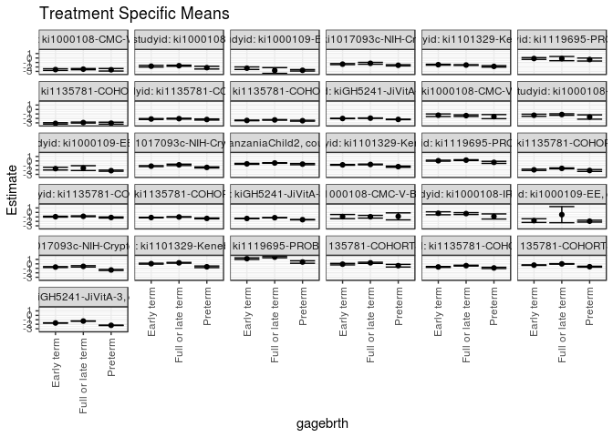

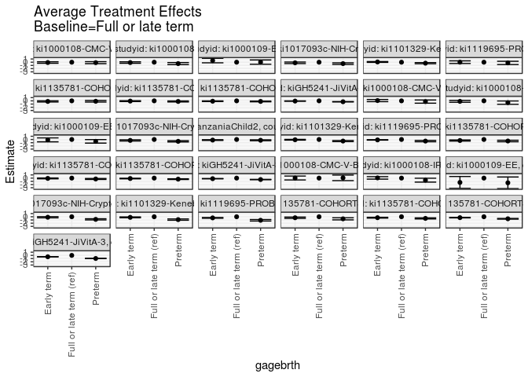

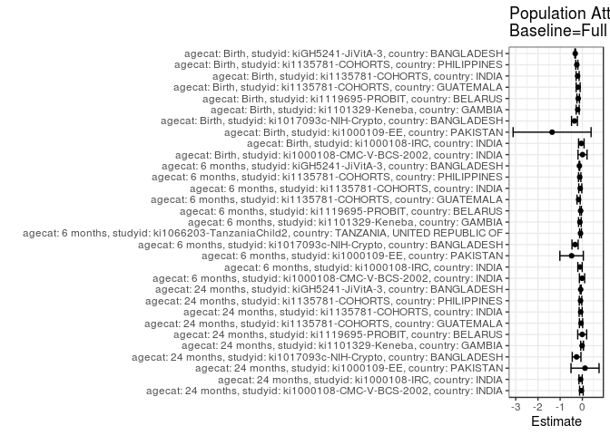

## Results Table

### Parameter: TSM

| agecat | studyid | country | intervention_level | baseline_level | estimate | ci_lower | ci_upper |
| --- | --- | --- | --- | --- | --- | --- | --- |
| Birth | ki1000108-CMC-V-BCS-2002 | INDIA | Full or late term | NA | -0.9690585 | -1.2770059 | -0.6611110 |
| Birth | ki1000108-CMC-V-BCS-2002 | INDIA | Preterm | NA | -0.8831072 | -1.6671574 | -0.0990571 |
| Birth | ki1000108-CMC-V-BCS-2002 | INDIA | Early term | NA | -0.9334477 | -1.4028462 | -0.4640492 |
| Birth | ki1000108-IRC | INDIA | Full or late term | NA | -0.2643301 | -0.4698541 | -0.0588061 |
| Birth | ki1000108-IRC | INDIA | Preterm | NA | -0.9032593 | -1.4745638 | -0.3319548 |
| Birth | ki1000108-IRC | INDIA | Early term | NA | -0.1907673 | -0.5218555 | 0.1403209 |
| Birth | ki1000109-EE | PAKISTAN | Full or late term | NA | -0.4983809 | -2.3037907 | 1.3070289 |
| Birth | ki1000109-EE | PAKISTAN | Preterm | NA | -1.9574204 | -2.1628149 | -1.7520260 |
| Birth | ki1000109-EE | PAKISTAN | Early term | NA | -1.8393610 | -2.2517310 | -1.4269910 |
| Birth | ki1017093c-NIH-Crypto | BANGLADESH | Full or late term | NA | -0.5547215 | -0.7026114 | -0.4068316 |
| Birth | ki1017093c-NIH-Crypto | BANGLADESH | Preterm | NA | -1.3654620 | -1.4781317 | -1.2527923 |
| Birth | ki1017093c-NIH-Crypto | BANGLADESH | Early term | NA | -0.7110500 | -0.8149055 | -0.6071946 |
| Birth | ki1101329-Keneba | GAMBIA | Full or late term | NA | 0.2385590 | 0.1516930 | 0.3254251 |
| Birth | ki1101329-Keneba | GAMBIA | Preterm | NA | -0.6512361 | -0.8330570 | -0.4694152 |
| Birth | ki1101329-Keneba | GAMBIA | Early term | NA | 0.0480983 | -0.0532748 | 0.1494714 |
| Birth | ki1119695-PROBIT | BELARUS | Full or late term | NA | 1.5142625 | 1.3601326 | 1.6683923 |
| Birth | ki1119695-PROBIT | BELARUS | Preterm | NA | 0.4158915 | 0.1420333 | 0.6897497 |
| Birth | ki1119695-PROBIT | BELARUS | Early term | NA | 1.1652417 | 0.9837089 | 1.3467744 |
| Birth | ki1135781-COHORTS | GUATEMALA | Full or late term | NA | 0.2429644 | 0.1188121 | 0.3671166 |
| Birth | ki1135781-COHORTS | GUATEMALA | Preterm | NA | -0.4048099 | -0.7014720 | -0.1081477 |
| Birth | ki1135781-COHORTS | GUATEMALA | Early term | NA | -0.0643205 | -0.2315446 | 0.1029037 |
| Birth | ki1135781-COHORTS | INDIA | Full or late term | NA | -0.3942142 | -0.4827458 | -0.3056827 |
| Birth | ki1135781-COHORTS | INDIA | Preterm | NA | -0.9033044 | -1.0430615 | -0.7635473 |
| Birth | ki1135781-COHORTS | INDIA | Early term | NA | -0.6847089 | -0.7833192 | -0.5860987 |
| Birth | ki1135781-COHORTS | PHILIPPINES | Full or late term | NA | -0.0003815 | -0.0586615 | 0.0578985 |
| Birth | ki1135781-COHORTS | PHILIPPINES | Preterm | NA | -0.6340083 | -0.7310734 | -0.5369432 |
| Birth | ki1135781-COHORTS | PHILIPPINES | Early term | NA | -0.2776989 | -0.3347675 | -0.2206303 |
| Birth | kiGH5241-JiVitA-3 | BANGLADESH | Full or late term | NA | -1.2769317 | -1.3004504 | -1.2534130 |
| Birth | kiGH5241-JiVitA-3 | BANGLADESH | Preterm | NA | -2.2350594 | -2.2797708 | -2.1903480 |
| Birth | kiGH5241-JiVitA-3 | BANGLADESH | Early term | NA | -1.7086056 | -1.7392346 | -1.6779766 |

[output cut: 63 more lines]

### Parameter: E(Y)

| agecat | studyid | country | intervention_level | baseline_level | estimate | ci_lower | ci_upper |
| --- | --- | --- | --- | --- | --- | --- | --- |
| Birth | ki1000108-CMC-V-BCS-2002 | INDIA | NA | NA | -0.9611957 | -1.1776967 | -0.7446946 |
| Birth | ki1000108-IRC | INDIA | NA | NA | -0.3102981 | -0.4751168 | -0.1454794 |
| Birth | ki1000109-EE | PAKISTAN | NA | NA | -1.8608750 | -2.0482045 | -1.6735455 |
| Birth | ki1017093c-NIH-Crypto | BANGLADESH | NA | NA | -0.9094945 | -0.9809370 | -0.8380521 |
| Birth | ki1101329-Keneba | GAMBIA | NA | NA | 0.0278680 | -0.0365315 | 0.0922674 |
| Birth | ki1119695-PROBIT | BELARUS | NA | NA | 1.3269446 | 1.1683850 | 1.4855041 |
| Birth | ki1135781-COHORTS | GUATEMALA | NA | NA | 0.0530794 | -0.0441925 | 0.1503513 |
| Birth | ki1135781-COHORTS | INDIA | NA | NA | -0.6072158 | -0.6675691 | -0.5468624 |
| Birth | ki1135781-COHORTS | PHILIPPINES | NA | NA | -0.2492460 | -0.2884729 | -0.2100192 |
| Birth | kiGH5241-JiVitA-3 | BANGLADESH | NA | NA | -1.5980879 | -1.6176172 | -1.5785586 |
| 6 months | ki1000108-CMC-V-BCS-2002 | INDIA | NA | NA | -1.3856004 | -1.5319935 | -1.2392073 |
| 6 months | ki1000108-IRC | INDIA | NA | NA | -1.2321263 | -1.3660720 | -1.0981806 |
| 6 months | ki1000109-EE | PAKISTAN | NA | NA | -2.0835567 | -2.2027557 | -1.9643578 |
| 6 months | ki1017093c-NIH-Crypto | BANGLADESH | NA | NA | -1.1986783 | -1.2700937 | -1.1272630 |
| 6 months | ki1066203-TanzaniaChild2 | TANZANIA, UNITED REPUBLIC OF | NA | NA | -0.5419570 | -0.5926042 | -0.4913098 |
| 6 months | ki1101329-Keneba | GAMBIA | NA | NA | -0.8948084 | -0.9510697 | -0.8385471 |
| 6 months | ki1119695-PROBIT | BELARUS | NA | NA | 0.1069986 | 0.0122286 | 0.2017686 |
| 6 months | ki1135781-COHORTS | GUATEMALA | NA | NA | -1.8315428 | -1.9081267 | -1.7549589 |
| 6 months | ki1135781-COHORTS | INDIA | NA | NA | -0.9630335 | -1.0220763 | -0.9039908 |
| 6 months | ki1135781-COHORTS | PHILIPPINES | NA | NA | -1.1409862 | -1.1830414 | -1.0989310 |
| 6 months | kiGH5241-JiVitA-3 | BANGLADESH | NA | NA | -1.3168751 | -1.3402193 | -1.2935309 |
| 24 months | ki1000108-CMC-V-BCS-2002 | INDIA | NA | NA | -2.5319389 | -2.6335015 | -2.4303762 |
| 24 months | ki1000108-IRC | INDIA | NA | NA | -1.7964915 | -1.8912047 | -1.7017782 |
| 24 months | ki1000109-EE | PAKISTAN | NA | NA | -2.6699900 | -2.8138051 | -2.5261749 |
| 24 months | ki1017093c-NIH-Crypto | BANGLADESH | NA | NA | -1.4412646 | -1.5249156 | -1.3576135 |
| 24 months | ki1101329-Keneba | GAMBIA | NA | NA | -1.5800865 | -1.6398819 | -1.5202911 |
| 24 months | ki1119695-PROBIT | BELARUS | NA | NA | -0.1314048 | -0.4282725 | 0.1654630 |
| 24 months | ki1135781-COHORTS | GUATEMALA | NA | NA | -2.9911195 | -3.0733804 | -2.9088586 |
| 24 months | ki1135781-COHORTS | INDIA | NA | NA | -2.1289450 | -2.1901830 | -2.0677069 |
| 24 months | ki1135781-COHORTS | PHILIPPINES | NA | NA | -2.4144884 | -2.4596605 | -2.3693164 |
| 24 months | kiGH5241-JiVitA-3 | BANGLADESH | NA | NA | -2.0156596 | -2.0439781 | -1.9873411 |

### Parameter: ATE

| agecat | studyid | country | intervention_level | baseline_level | estimate | ci_lower | ci_upper |
| --- | --- | --- | --- | --- | --- | --- | --- |
| Birth | ki1000108-CMC-V-BCS-2002 | INDIA | Full or late term | Full or late term | 0.0000000 | 0.0000000 | 0.0000000 |
| Birth | ki1000108-CMC-V-BCS-2002 | INDIA | Preterm | Full or late term | 0.0859512 | -0.7796148 | 0.9515172 |
| Birth | ki1000108-CMC-V-BCS-2002 | INDIA | Early term | Full or late term | 0.0356107 | -0.5707588 | 0.6419803 |
| Birth | ki1000108-IRC | INDIA | Full or late term | Full or late term | 0.0000000 | 0.0000000 | 0.0000000 |
| Birth | ki1000108-IRC | INDIA | Preterm | Full or late term | -0.6389292 | -1.2466339 | -0.0312246 |
| Birth | ki1000108-IRC | INDIA | Early term | Full or late term | 0.0735628 | -0.3161667 | 0.4632922 |
| Birth | ki1000109-EE | PAKISTAN | Full or late term | Full or late term | 0.0000000 | 0.0000000 | 0.0000000 |
| Birth | ki1000109-EE | PAKISTAN | Preterm | Full or late term | -1.4590395 | -3.2751100 | 0.3570310 |
| Birth | ki1000109-EE | PAKISTAN | Early term | Full or late term | -1.3409801 | -3.1940590 | 0.5120989 |
| Birth | ki1017093c-NIH-Crypto | BANGLADESH | Full or late term | Full or late term | 0.0000000 | 0.0000000 | 0.0000000 |
| Birth | ki1017093c-NIH-Crypto | BANGLADESH | Preterm | Full or late term | -0.8107404 | -0.9965861 | -0.6248948 |
| Birth | ki1017093c-NIH-Crypto | BANGLADESH | Early term | Full or late term | -0.1563285 | -0.3367694 | 0.0241124 |
| Birth | ki1101329-Keneba | GAMBIA | Full or late term | Full or late term | 0.0000000 | 0.0000000 | 0.0000000 |
| Birth | ki1101329-Keneba | GAMBIA | Preterm | Full or late term | -0.8897951 | -1.0913485 | -0.6882417 |
| Birth | ki1101329-Keneba | GAMBIA | Early term | Full or late term | -0.1904607 | -0.3241168 | -0.0568047 |
| Birth | ki1119695-PROBIT | BELARUS | Full or late term | Full or late term | 0.0000000 | 0.0000000 | 0.0000000 |
| Birth | ki1119695-PROBIT | BELARUS | Preterm | Full or late term | -1.0983710 | -1.3358765 | -0.8608654 |
| Birth | ki1119695-PROBIT | BELARUS | Early term | Full or late term | -0.3490208 | -0.4719303 | -0.2261113 |
| Birth | ki1135781-COHORTS | GUATEMALA | Full or late term | Full or late term | 0.0000000 | 0.0000000 | 0.0000000 |
| Birth | ki1135781-COHORTS | GUATEMALA | Preterm | Full or late term | -0.6477742 | -0.9690130 | -0.3265355 |
| Birth | ki1135781-COHORTS | GUATEMALA | Early term | Full or late term | -0.3072848 | -0.5146332 | -0.0999365 |
| Birth | ki1135781-COHORTS | INDIA | Full or late term | Full or late term | 0.0000000 | 0.0000000 | 0.0000000 |
| Birth | ki1135781-COHORTS | INDIA | Preterm | Full or late term | -0.5090902 | -0.6745386 | -0.3436417 |
| Birth | ki1135781-COHORTS | INDIA | Early term | Full or late term | -0.2904947 | -0.4228098 | -0.1581796 |
| Birth | ki1135781-COHORTS | PHILIPPINES | Full or late term | Full or late term | 0.0000000 | 0.0000000 | 0.0000000 |
| Birth | ki1135781-COHORTS | PHILIPPINES | Preterm | Full or late term | -0.6336268 | -0.7467563 | -0.5204973 |
| Birth | ki1135781-COHORTS | PHILIPPINES | Early term | Full or late term | -0.2773174 | -0.3587482 | -0.1958866 |
| Birth | kiGH5241-JiVitA-3 | BANGLADESH | Full or late term | Full or late term | 0.0000000 | 0.0000000 | 0.0000000 |
| Birth | kiGH5241-JiVitA-3 | BANGLADESH | Preterm | Full or late term | -0.9581277 | -1.0091044 | -0.9071510 |
| Birth | kiGH5241-JiVitA-3 | BANGLADESH | Early term | Full or late term | -0.4316739 | -0.4674489 | -0.3958989 |

[output cut: 63 more lines]

### Parameter: PAR

| agecat | studyid | country | intervention_level | baseline_level | estimate | ci_lower | ci_upper |
| --- | --- | --- | --- | --- | --- | --- | --- |
| Birth | ki1000108-CMC-V-BCS-2002 | INDIA | Full or late term | NA | 0.0078628 | -0.1945519 | 0.2102775 |
| Birth | ki1000108-IRC | INDIA | Full or late term | NA | -0.0459680 | -0.1701923 | 0.0782563 |
| Birth | ki1000109-EE | PAKISTAN | Full or late term | NA | -1.3624941 | -3.1182984 | 0.3933102 |
| Birth | ki1017093c-NIH-Crypto | BANGLADESH | Full or late term | NA | -0.3547730 | -0.4867871 | -0.2227589 |
| Birth | ki1101329-Keneba | GAMBIA | Full or late term | NA | -0.2106910 | -0.2777488 | -0.1436333 |
| Birth | ki1119695-PROBIT | BELARUS | Full or late term | NA | -0.1873179 | -0.2454238 | -0.1292121 |
| Birth | ki1135781-COHORTS | GUATEMALA | Full or late term | NA | -0.1898849 | -0.2784448 | -0.1013251 |
| Birth | ki1135781-COHORTS | INDIA | Full or late term | NA | -0.2130016 | -0.2812560 | -0.1447471 |
| Birth | ki1135781-COHORTS | PHILIPPINES | Full or late term | NA | -0.2488645 | -0.2969678 | -0.2007612 |
| Birth | kiGH5241-JiVitA-3 | BANGLADESH | Full or late term | NA | -0.3211562 | -0.3387754 | -0.3035369 |
| 6 months | ki1000108-CMC-V-BCS-2002 | INDIA | Full or late term | NA | -0.0156719 | -0.1337782 | 0.1024344 |
| 6 months | ki1000108-IRC | INDIA | Full or late term | NA | -0.1050517 | -0.2040375 | -0.0060659 |
| 6 months | ki1000109-EE | PAKISTAN | Full or late term | NA | -0.4834761 | -1.0124829 | 0.0455306 |
| 6 months | ki1017093c-NIH-Crypto | BANGLADESH | Full or late term | NA | -0.3278417 | -0.4665261 | -0.1891573 |
| 6 months | ki1066203-TanzaniaChild2 | TANZANIA, UNITED REPUBLIC OF | Full or late term | NA | -0.0840407 | -0.1243743 | -0.0437071 |
| 6 months | ki1101329-Keneba | GAMBIA | Full or late term | NA | -0.1109128 | -0.1693562 | -0.0524693 |
| 6 months | ki1119695-PROBIT | BELARUS | Full or late term | NA | -0.0777684 | -0.1107438 | -0.0447931 |
| 6 months | ki1135781-COHORTS | GUATEMALA | Full or late term | NA | -0.1690193 | -0.2398953 | -0.0981432 |
| 6 months | ki1135781-COHORTS | INDIA | Full or late term | NA | -0.0945143 | -0.1624171 | -0.0266115 |
| 6 months | ki1135781-COHORTS | PHILIPPINES | Full or late term | NA | -0.1188760 | -0.1711375 | -0.0666146 |
| 6 months | kiGH5241-JiVitA-3 | BANGLADESH | Full or late term | NA | -0.1327772 | -0.1497855 | -0.1157688 |
| 24 months | ki1000108-CMC-V-BCS-2002 | INDIA | Full or late term | NA | -0.0434631 | -0.1241086 | 0.0371825 |
| 24 months | ki1000108-IRC | INDIA | Full or late term | NA | -0.0793882 | -0.1521685 | -0.0066079 |
| 24 months | ki1000109-EE | PAKISTAN | Full or late term | NA | 0.1207243 | -0.5112745 | 0.7527231 |
| 24 months | ki1017093c-NIH-Crypto | BANGLADESH | Full or late term | NA | -0.2595986 | -0.4553918 | -0.0638054 |
| 24 months | ki1101329-Keneba | GAMBIA | Full or late term | NA | -0.0119016 | -0.0733647 | 0.0495616 |
| 24 months | ki1119695-PROBIT | BELARUS | Full or late term | NA | -0.0069937 | -0.2084479 | 0.1944605 |
| 24 months | ki1135781-COHORTS | GUATEMALA | Full or late term | NA | -0.0592285 | -0.1318563 | 0.0133993 |
| 24 months | ki1135781-COHORTS | INDIA | Full or late term | NA | -0.0767902 | -0.1451566 | -0.0084239 |
| 24 months | ki1135781-COHORTS | PHILIPPINES | Full or late term | NA | -0.0821261 | -0.1381636 | -0.0260887 |
| 24 months | kiGH5241-JiVitA-3 | BANGLADESH | Full or late term | NA | -0.0762369 | -0.0985492 | -0.0539247 |